# Global Carbon Emissions for Food Types

4/15/2020

```r
library(tidyverse)
library(ggformula)
```

```r
library(mosaic)
```

## Motivation

- We want to research the environmental impact that the food industry and diet have on carbon footprint
- Are carbon emissions for meat and nonmeat foods equal?

## Background

- The data is from 2013, and was collected and aggregated in 2018 by nu3, a German health food company. Kasia Kulma used web scraping to collect and format the data for the Tidy Tuesday challenge for the week of February 18, 2020. https://www.nu3.de/blogs/nutrition/food-carbon-footprint-index-2018

[figure not shown]

## Methods

## Methods Slide 1 - Data Collection

The data was obtained from Github - Tidy Tuesday, and cleaned and reformatted in R.

\(H_0: \theta = 217.84\) The population median of CO2 emissions for meat products is equal to the CO2 emissions for non-meat products.

## Methods Slide 2 - Analytic Methods

- Nonparametric methods are used because the data for carbon emissions is skewed right.

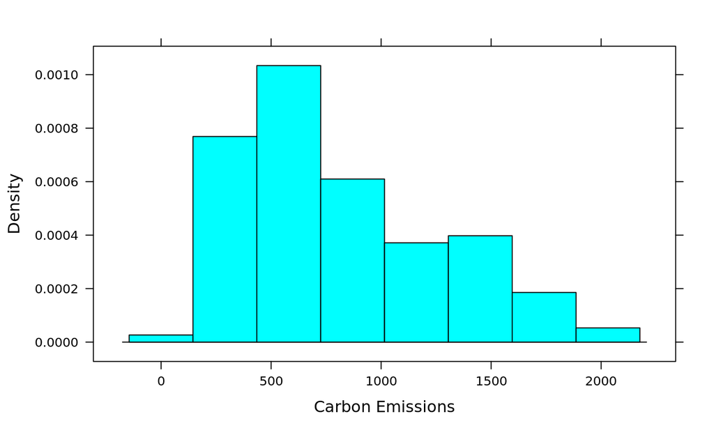

## Results

## Summary Statistics and Graphics

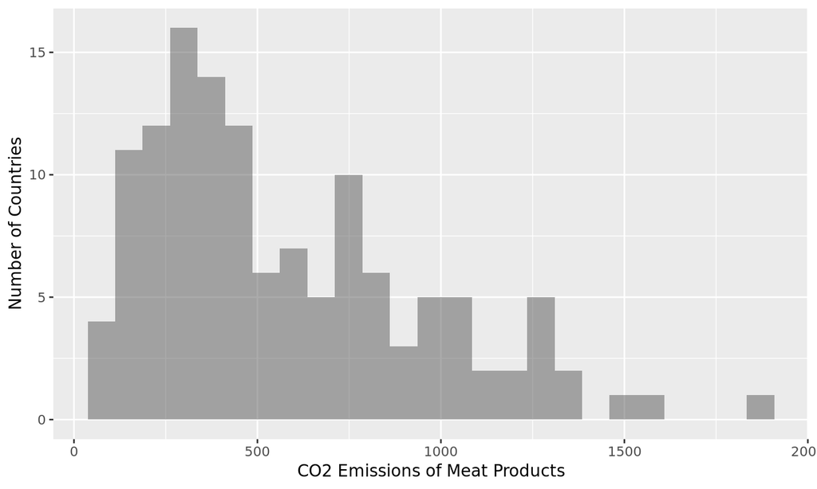

## Summary Statistics and Graphics

Since the data for the CO2 meat column is right skewed, the population median, \(\theta\), is a better value than population mean \(\mu\) to use for measuring central tendency.

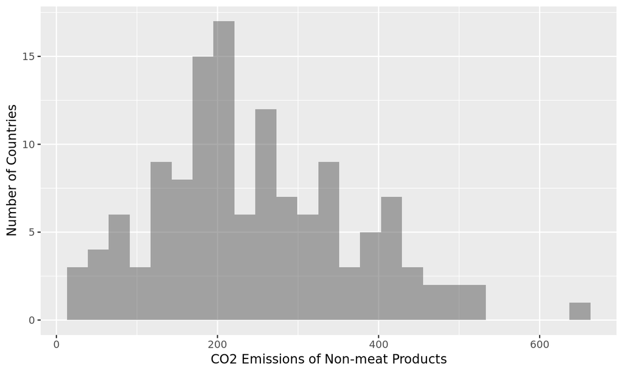

## Summary Statistics and Graphics

```
[1] "CO2 of Non-meat products"
```

```
   Min. 1st Qu.  Median    Mean 3rd Qu.    Max.
  25.64  167.13  217.84  245.60  326.12  649.75
```

```
[1] "CO2 of Meat products"
```

```
   Min. 1st Qu.  Median    Mean 3rd Qu.    Max.
  55.83  274.30  446.89  572.62  787.79 1852.32
```

## Analysis

```
co2_meat > 217.84
 TRUE FALSE
  110    20
```

```
[1] 1.495713e-16
```

> There is a 1.496e-16 probability of observing 110 or more values about the true median assuming the true median is = 217.84 kgs/year of co2 emissions, which means that it is HIGHLY unlikely for these numbers to be found by chance. Therefore, we reject the null hypothesis that the CO_2 emissions for meat and nonmeat foods are equivalent, and support the alternative hypothesis that meat foods have greater carbon emissions than nonmeat foods.

## Summary

## Conclusion

> Based on our binomial test, we conclude that there is a significant difference between the emissions associated with producing meat and the emissions associated with producing non-meat foods.

## Future Work

> The data should be gathered and tested for more years than just 2013, so as to attempt to establish a trend.

## References

https://github.com/rfordatascience/tidytuesday/blob/master/data/2020/2020-02-18/readme.md

https://www.nu3.de/blogs/nutrition/food-carbon-footprint-index-2018